# Univariate HW

Amanda Bayless

January 28, 2018

```r
knitr::opts_chunk$set(echo = TRUE)
knitr::opts_chunk$set(root.dir="~/Graduate Program/Applied Quantitative Methods/homework/Homework Univariate")
```

```r
trees = read.csv("treedata_subset.csv")
trees
trees_Abies <- trees[trees$species == "Abies fraseri",]
trees_Acer <- trees[trees$species == "Acer rubrum",]
```

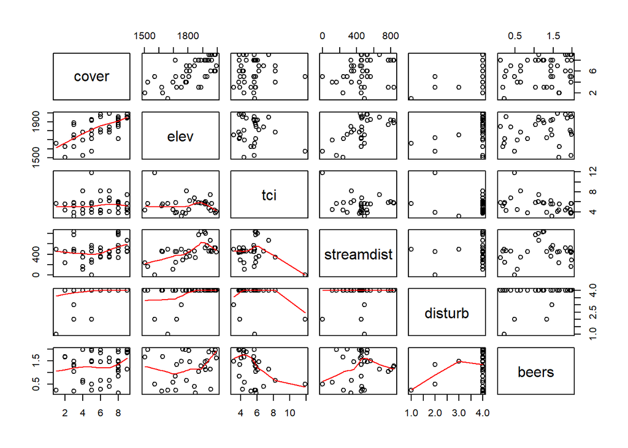

```r
pairs(trees_Abies[ , -c(1,2,3)], lower.panel = panel.smooth)
```

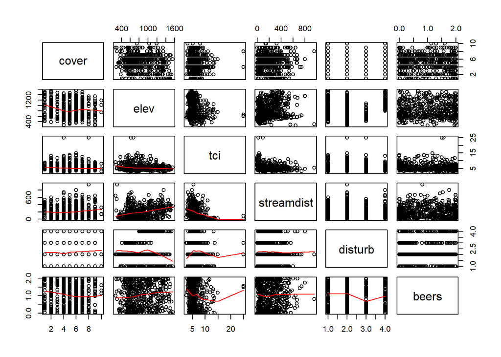

```r
pairs(trees_Acer[ , -c(1,2,3)], lower.panel = panel.smooth)
```

# Question 1. Carry out an exploratory analysis using the tree dataset. Develop and compare models for species cover for a habitat generalist Acer rubrum (Red maple) and a habitat specialist Abies fraseri (Frasier fir).

```r
library(car)
abies_ols <- lm(trees_Abies$cover ~ trees_Abies$elev +  trees_Abies$tci + trees_Abies$streamdist + trees_Abies$disturb + trees_Abies$beers)
summary(abies_ols)
```

```
##
## Call:
## lm(formula = trees_Abies$cover ~ trees_Abies$elev + trees_Abies$tci +
##     trees_Abies$streamdist + trees_Abies$disturb + trees_Abies$beers)
##
## Residuals:
##     Min      1Q  Median      3Q     Max
## -3.4630 -0.6472  0.0788  1.0872  3.8017
##
## Coefficients:
##                             Estimate Std. Error t value Pr(>|t|)
## (Intercept)               -20.561173   4.271449  -4.814 2.65e-05 ***
## trees_Abies$elev            0.012370   0.002523   4.903 2.02e-05 ***
## trees_Abies$tci             0.287641   0.193467   1.487   0.1458
## trees_Abies$streamdist     -0.001266   0.001585  -0.799   0.4296
## trees_Abies$disturbLT-SEL   2.188367   2.097905   1.043   0.3038
## trees_Abies$disturbSETTLE   1.527604   2.341471   0.652   0.5183
## trees_Abies$disturbVIRGIN   3.025596   1.735921   1.743   0.0899 .
## trees_Abies$beers           0.037551   0.500269   0.075   0.9406
## ---
## Signif. codes:  0 '***' 0.001 '**' 0.01 '*' 0.05 '.' 0.1 ' ' 1
##
## Residual standard error: 1.601 on 36 degrees of freedom
## Multiple R-squared:  0.5824, Adjusted R-squared:  0.5011
## F-statistic: 7.171 on 7 and 36 DF,  p-value: 2.215e-05
```

```r
Anova(abies_ols, type = 3)
```

```
## Anova Table (Type III tests)
##
## Response: trees_Abies$cover
##                        Sum Sq Df F value    Pr(>F)
## (Intercept)            59.401  1 23.1710 2.652e-05 ***
## trees_Abies$elev       61.618  1 24.0358 2.022e-05 ***
## trees_Abies$tci         5.667  1  2.2105    0.1458
## trees_Abies$streamdist  1.636  1  0.6382    0.4296
## trees_Abies$disturb    10.089  3  1.3118    0.2855
## trees_Abies$beers       0.014  1  0.0056    0.9406
## Residuals              92.289 36
## ---
## Signif. codes:  0 '***' 0.001 '**' 0.01 '*' 0.05 '.' 0.1 ' ' 1
```

```r
acer_ols <- lm(trees_Acer$cover ~ trees_Acer$elev + trees_Acer$tci + trees_Acer$streamdist + trees_Acer$disturb + trees_Acer$beers)
summary(acer_ols)
```

```
##
## Call:
## lm(formula = trees_Acer$cover ~ trees_Acer$elev + trees_Acer$tci +
##     trees_Acer$streamdist + trees_Acer$disturb + trees_Acer$beers)
##
## Residuals:
##     Min      1Q  Median      3Q     Max
## -4.7073 -1.2446  0.3409  1.3575  5.2732
##
## Coefficients:
##                            Estimate Std. Error t value Pr(>|t|)
## (Intercept)               6.3502303  0.4564973  13.911  < 2e-16 ***
## trees_Acer$elev          -0.0010108  0.0003161  -3.197  0.00145 **
## trees_Acer$tci           -0.0627613  0.0351922  -1.783  0.07495 .
## trees_Acer$streamdist     0.0012895  0.0004756   2.712  0.00686 **
## trees_Acer$disturbLT-SEL  0.0829610  0.2166747   0.383  0.70192
## trees_Acer$disturbSETTLE -0.1044556  0.2804213  -0.372  0.70963
## trees_Acer$disturbVIRGIN  0.3088364  0.2518161   1.226  0.22044
## trees_Acer$beers         -0.3269597  0.1089662  -3.001  0.00279 **
## ---
## Signif. codes:  0 '***' 0.001 '**' 0.01 '*' 0.05 '.' 0.1 ' ' 1
##
## Residual standard error: 1.989 on 715 degrees of freedom
## Multiple R-squared:  0.04493,    Adjusted R-squared:  0.03558
## F-statistic: 4.805 on 7 and 715 DF,  p-value: 2.669e-05
```

```r
Anova(acer_ols, type = 3)
```

```
## Anova Table (Type III tests)
##
## Response: trees_Acer$cover
##                        Sum Sq  Df  F value    Pr(>F)
## (Intercept)            765.43   1 193.5096 < 2.2e-16 ***
## trees_Acer$elev         40.44   1  10.2233  0.001448 **
## trees_Acer$tci          12.58   1   3.1805  0.074947 .
## trees_Acer$streamdist   29.09   1   7.3531  0.006856 **
## trees_Acer$disturb       9.45   3   0.7962  0.496166
## trees_Acer$beers        35.61   1   9.0034  0.002789 **
## Residuals             2828.21 715
## ---
## Signif. codes:  0 '***' 0.001 '**' 0.01 '*' 0.05 '.' 0.1 ' ' 1
```

The Anova and summary functions provide the same p-values except for the variable disturbance. Using the summary function causes disturbance to be split into three different categories. Anova just examines the overall significance of disturbance.

**Questions:**

- **How well does the exploratory model appear to explain cover?**

- **Which explanatory variables are the most important?**

For Abies elevation is the most important variable and for Acer the most important variables are elevation, stream distance and beers.

- **Do model diagnostics indicate any problems with violations of OLS assumptions?**

- **Are you able to explain variance in one species better than another, why might this be the case?**

The explained variance was calculated using the psuedo-r-squared statistic and it showed that variance was better explained in the Abies species. This may be the case because cover is only significantly caused by elevation (1 variable) while Acer species has 3 variables showing they are correlated with cover. There may also be variables interacting with one another preventing the model from being able to account for variation as well as Abies.

```r
Abies_ols2 <- lm(cover ~ elev, data = trees_Abies)
summary(Abies_ols2)
```

```
##
## Call:
## lm(formula = cover ~ elev, data = trees_Abies)
##
## Residuals:
##    Min     1Q Median     3Q    Max
## -3.679 -1.488  0.488  1.214  3.418
##
## Coefficients:
##               Estimate Std. Error t value Pr(>|t|)
## (Intercept) -15.814670   3.526227  -4.485 5.56e-05 ***
## elev          0.011914   0.001919   6.208 1.99e-07 ***
## ---
## Signif. codes:  0 '***' 0.001 '**' 0.01 '*' 0.05 '.' 0.1 ' ' 1
##
## Residual standard error: 1.656 on 42 degrees of freedom
## Multiple R-squared:  0.4786, Adjusted R-squared:  0.4661
## F-statistic: 38.54 on 1 and 42 DF,  p-value: 1.991e-07
```

```r
Anova(Abies_ols2, type = 3)
```

```
## Anova Table (Type III tests)
##
## Response: cover
##              Sum Sq Df F value    Pr(>F)
## (Intercept)  55.184  1  20.114 5.561e-05 ***
## elev        105.749  1  38.545 1.991e-07 ***
## Residuals   115.229 42
## ---
## Signif. codes:  0 '***' 0.001 '**' 0.01 '*' 0.05 '.' 0.1 ' ' 1
```

```r
mean(Abies_ols2$residuals)
```

```
## [1] -7.944953e-17
```

```r
Acer_ols2 <- lm(cover ~ elev + streamdist + beers, data = trees_Acer)
summary(Acer_ols2)
```

```
##
## Call:
## lm(formula = cover ~ elev + streamdist + beers, data = trees_Acer)
##
## Residuals:
##     Min      1Q  Median      3Q     Max
## -4.9339 -1.3307  0.2865  1.3691  5.2839
##
## Coefficients:
##               Estimate Std. Error t value Pr(>|t|)
## (Intercept)  5.8119219  0.2420805  24.008  < 2e-16 ***
## elev        -0.0008226  0.0002589  -3.178 0.001548 **
## streamdist   0.0015415  0.0004566   3.376 0.000774 ***
## beers       -0.3034710  0.1067192  -2.844 0.004587 **
## ---
## Signif. codes:  0 '***' 0.001 '**' 0.01 '*' 0.05 '.' 0.1 ' ' 1
##
## Residual standard error: 1.992 on 719 degrees of freedom
## Multiple R-squared:  0.03688,    Adjusted R-squared:  0.03287
## F-statistic: 9.178 on 3 and 719 DF,  p-value: 5.775e-06
```

```r
Anova(Acer_ols2, type = 3)
```

```
## Anova Table (Type III tests)
##
## Response: cover
##              Sum Sq  Df  F value    Pr(>F)
## (Intercept) 2286.36   1 576.3946 < 2.2e-16 ***
## elev          40.05   1  10.0977  0.001548 **
## streamdist    45.22   1  11.4000  0.000774 ***
## beers         32.08   1   8.0863  0.004587 **
## Residuals   2852.03 719
## ---
## Signif. codes:  0 '***' 0.001 '**' 0.01 '*' 0.05 '.' 0.1 ' ' 1
```